# Estimation of subnational fertility in SSA

Oli Stevens

2019-07-23

This is some intro text about how I went and did the thing.

## Load packages

```r
library(tidyverse)
library(rdhs)
library(demogsurv)
library(lme4)
```

## Calculate ASFR, TFR, and GFR

Use `rdhs` and `demogsurv` to calculate ASFR & TFR for Malawi.

```r
##+ datasets
surveys <- dhs_surveys(countryIds = "MW", surveyYearStart=1995)
```

[output not shown]

```r
ird <- dhs_datasets(fileType = "IR", fileFormat = "flat", surveyIds = surveys$SurveyId)
ird$path <- unlist(get_datasets(ird))
```

## Load the datasets into R as a list and asssign survey-level variables

```r
ir <- lapply(ird$path, readRDS) %>%
  Map(data.frame,
      surveyid = surveys$SurveyId,
      country = surveys$CountryName,
      survyear = surveys$SurveyYear,
      survtype = surveys$SurveyType,
      .,
      stringsAsFactors = FALSE)
```

## Calculate TFR

Calculate annual (calendar periods) TFR estimates for 0-10 years preceding each DHS survey or 0 to 5 years preceding each MIS.

```r
tips_surv <- list("DHS" = c(0, 10), "MIS" = c(0, 5))[surveys$SurveyType]
```

Calculate TFR by survey year & urban/rural (`v025`)

```r
tfr <- Map(calc_tfr, ir,
           by = list(~surveyid + country + survyear + v025),
           tips = tips_surv,
           period = list(1995:2017))

tfr <- tfr %>%
  bind_rows %>%
  type.convert %>%
  mutate(v025 = factor(v025, levels= c(1,2), labels = c("Urban", "Rural"))) %>%
  filter(period <= survyear) %>%
  mutate(lower = tfr - qnorm(0.975) * se_tfr,
         upper = tfr + qnorm(0.975) * se_tfr)
```

## Plot annual TFR estimates

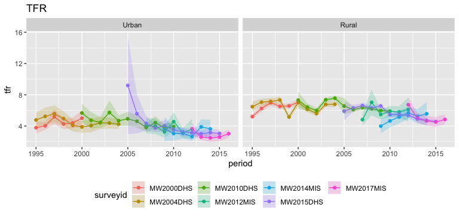

# Fixed effects model

## Calculate ASFR and births / PYs

```r
asfr <- Map(calc_asfr, ir,
            by = list(~surveyid + country + survyear+ v025),
            tips = tips_surv,
            period = list(1995:2017),
            counts = TRUE)


asfr <- asfr %>%
  bind_rows %>%
  type.convert %>%
  mutate(v025 = factor(v025, levels= c(1,2), labels = c("Urban", "Rural"))) %>%
  filter(period <= survyear)
```

## Fit model

Fit Poisson GLM with log-linear time trend for each age group & fixed effect for urbal/rural

```r
mod <- glm(births ~ agegr*period + v025, family = poisson, data = asfr, offset = log(pys))
```

## Generate predictions for ASFR

Create a data frame for values to predict—all age groups in each year from 1995 through 2017.

```r
df_pred <- crossing(period = 1995:2017,
                    agegr = levels(asfr$agegr),
                    pys = 1,
                    v025 = levels(asfr$v025))
```

Generate predictions log ASFR and return standard error

```r
pred<- predict(mod, newdata = df_pred, se.fit = TRUE)


df_pred <- data.frame(df_pred, pred) %>%
  mutate(asfr = exp(fit),
         lower = exp(fit - qnorm(0.975) * se.fit),
         upper = exp(fit + qnorm(0.975) * se.fit))
```

Plot predicted vs. observed ASFR.

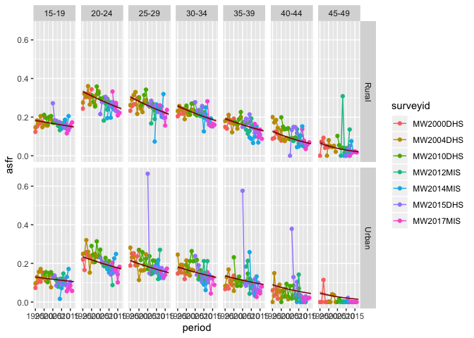

Outliers in 2015 DHS in urban areas:

```
#>    surveyid  v025 agegr period tips   births       pys      asfr   se_asfr
#> 1 MW2015DHS Urban 25-29   2005  0-9 9.852146 14.828159 0.6644214 0.3763539
#> 2 MW2015DHS Urban 35-39   2005  0-9 4.023021  6.982684 0.5761425 0.4403703
#> 3 MW2015DHS Urban 40-44   2006  0-9 6.860187 18.100340 0.3790087 0.2354566
```

# Mixed effects model

Introduce random intercept and slope for age group over time.

`mod2 <- glmer(births ~ agegr*period + v025 + (1 + period | agegr) , family = poisson, data = asfr2, offset = log(pys))`

Fails to fit. Reduce the TIPS of the DHS surveys to 0-7:

```r
Map(calc_asfr, ir,
              by = list(~surveyid + country + survyear+ v025),
              tips = list("DHS" = c(0, 7), "MIS" = c(0, 5))[surveys$SurveyType],
              period = list(1995:2017),
              counts = TRUE)
```

Still fails to fit.

Collapse top 2 age groups to reduce 0 counts. Tried to do this through the `agegr` argument in `calc_asfr` but couldn’t resolve `Error in tcut(data[[tstart]] - data[[dob]], agegr * scale, .epis_labels(agegr)) : Number of labels must equal number of intervals` in `demog_pyears()`. Messy code:

```r
asfr2 <- asfr %>%
  mutate(births = round(births),
           pys = round(pys),
           sum_var = ifelse(agegr=="40-44" | agegr=="45-49", TRUE, FALSE)) %>%
    group_by(surveyid, country,  survyear,tips,  v025, period, sum_var) %>%
    mutate(births = ifelse(sum_var, sum(births), births),
           pys = ifelse(sum_var, sum(pys), pys),
           asfr = births/pys,
           agegr = plyr::revalue(agegr, c("40-44" = "40-49")),
           agegr = factor(agegr, levels=c("15-19", "20-24", "25-29", "30-34", "35-39", "40-49"))
    ) %>%
    droplevels() %>%
    ungroup() %>%
    select(-sum_var) %>%
    distinct(surveyid, country, survyear, tips,v025, period, births, pys, asfr, .keep_all=TRUE)
```

Model run throws an error: `Error in (function (fr, X, reTrms, family, nAGQ = 1L, verbose = 0L, maxit = 100L, : (maxstephalfit) PIRLS step-halvings failed to reduce deviance in pwrssUpdate`.

Combine both the shortened DHS TIPS and the collapsed upper age groups. Does run, though reports an error of being a singular fit. The random effects don’t add anything to the model at this stage (which is the intepretation of the very small variances around them below - i.e. variation is adequately explained by the fixed effects?)

```
#> boundary (singular) fit: see ?isSingular
#> Generalized linear mixed model fit by maximum likelihood (Laplace Approximation) ['glmerMod']
#>  Family: poisson  ( log )
#> Formula: births ~ agegr * period + v025 + (1 + period | agegr)
#>    Data: asfr2
#>  Offset: log(pys)
#>
#>      AIC      BIC   logLik deviance df.resid
#>   5177.5   5246.9  -2572.8   5145.5      548
#>
#> Scaled residuals:
#>     Min      1Q  Median      3Q     Max
#> -7.1502 -1.2057 -0.2028  1.0000  7.7309
#>
#> Random effects:
#>  Groups Name        Variance  Std.Dev.  Corr
#>  agegr  (Intercept) 1.013e-05 3.183e-03
#>         period      2.517e-12 1.587e-06 -1.00
#> Number of obs: 564, groups:  agegr, 6
#>
#> Fixed effects:
#>                    Estimate Std. Error z value Pr(>|z|)
#> (Intercept)       14.765920   2.590710   5.700 1.20e-08 ***
#> agegr20-24        14.110481   3.339531   4.225 2.39e-05 ***
#> agegr25-29        14.510017   3.624721   4.003 6.25e-05 ***
#> agegr30-34        14.796318   4.014727   3.686 0.000228 ***
#> agegr35-39        18.592294   4.830653   3.849 0.000119 ***
#> agegr40-49        52.832218   6.445261   8.197 2.46e-16 ***
#> period            -0.008448   0.001291  -6.542 6.07e-11 ***
#> v025Rural          0.367613   0.009901  37.128  < 2e-16 ***
#> agegr20-24:period -0.006755   0.001665  -4.058 4.95e-05 ***
#> agegr25-29:period -0.007010   0.001807  -3.880 0.000104 ***
#> agegr30-34:period -0.007242   0.002001  -3.619 0.000295 ***
#> agegr35-39:period -0.009294   0.002408  -3.860 0.000113 ***
#> agegr40-49:period -0.026742   0.003213  -8.322  < 2e-16 ***
#> ---
#> Signif. codes:  0 '***' 0.001 '**' 0.01 '*' 0.05 '.' 0.1 ' ' 1
#>
#> Correlation matrix not shown by default, as p = 13 > 12.
#> Use print(x, correlation=TRUE)  or
#>     vcov(x)        if you need it
#> convergence code: 0
#> boundary (singular) fit: see ?isSingular
```

## Predict & plot ASFRs

As before - prediction data frame. `se.fit` not available within `lme4` so no uncertainty around fitted ASFRs

```r
df_pred2 <- crossing(period = 1995:2017,
                       agegr = levels(asfr2$agegr),
                       pys = 1,
                       v025 = levels(asfr2$v025))

  pred2 <- predict(mod2, newdata = df_pred2)

  df_pred2 <- data.frame(df_pred2, pred2) %>%
    mutate(asfr = exp(pred2))
```

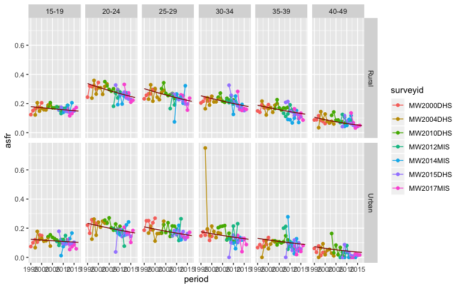